```python
import pandas as pd
from sklearn.preprocessing import LabelEncoder
```

# Data Architecture

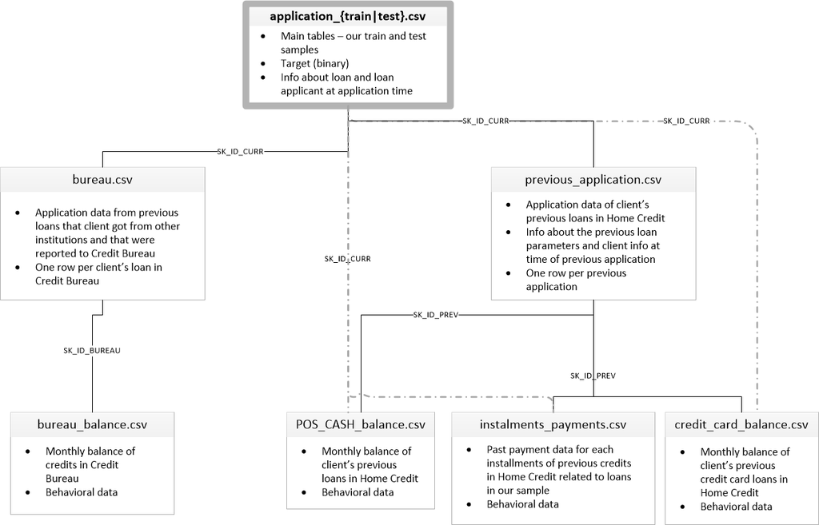

# 1. Application data - Main data tables(Train, Test)

This is the main table, broken into two files for Train (with TARGET) and Test (without TARGET). Static data for all applications. One row represents one loan in our data sample.

##### 1.1 Reading the application_train.csv & application_test datasets

```python
train = pd.read_csv('Data/application_train.csv')
test = pd.read_csv('Data/application_test.csv')
```

```python
print(train.shape)
print(test.shape)
```

```
(307511, 122)
(48744, 121)
```

##### 1.2 Feature Engineering & Conversion of categorical features

```python
categorical_features = [col for col in train.columns if train[col].dtype == 'object']
one_hot_df = pd.concat([train,test])
one_hot_df = pd.get_dummies(one_hot_df, columns=categorical_features)
train = one_hot_df.iloc[:train.shape[0],:]
test = one_hot_df.iloc[train.shape[0]:,]
```

```python
train.describe(include='all')
```

|  | SK_ID_CURR | TARGET | CNT_CHILDREN | AMT_INCOME_TOTAL | AMT_CREDIT | AMT_ANNUITY | AMT_GOODS_PRICE | REGION_POPULATION_RELATIVE | DAYS_BIRTH | DAYS_EMPLOYED | ... | HOUSETYPE_MODE_terraced house | WALLSMATERIAL_MODE_Block | WALLSMATERIAL_MODE_Mixed | WALLSMATERIAL_MODE_Monolithic | WALLSMATERIAL_MODE_Others | WALLSMATERIAL_MODE_Panel | WALLSMATERIAL_MODE_Stone, brick | WALLSMATERIAL_MODE_Wooden | EMERGENCYSTATE_MODE_No | EMERGENCYSTATE_MODE_Yes |
| --- | --- | --- | --- | --- | --- | --- | --- | --- | --- | --- | --- | --- | --- | --- | --- | --- | --- | --- | --- | --- | --- |
| count | 307511.000000 | 307511.000000 | 307511.000000 | 3.075110e+05 | 3.075110e+05 | 307499.000000 | 3.072330e+05 | 307511.000000 | 307511.000000 | 307511.000000 | ... | 307511.000000 | 307511.000000 | 307511.000000 | 307511.000000 | 307511.000000 | 307511.000000 | 307511.000000 | 307511.000000 | 307511.000000 | 307511.000000 |
| mean | 278180.518577 | 0.080729 | 0.417052 | 1.687979e+05 | 5.990260e+05 | 27108.573909 | 5.383962e+05 | 0.020868 | -16036.995067 | 63815.045904 | ... | 0.003941 | 0.030090 | 0.007466 | 0.005785 | 0.005284 | 0.214757 | 0.210773 | 0.017437 | 0.518446 | 0.007570 |
| std | 102790.175348 | 0.272419 | 0.722121 | 2.371231e+05 | 4.024908e+05 | 14493.737315 | 3.694465e+05 | 0.013831 | 4363.988632 | 141275.766519 | ... | 0.062656 | 0.170835 | 0.086085 | 0.075840 | 0.072501 | 0.410654 | 0.407858 | 0.130892 | 0.499660 | 0.086679 |
| min | 100002.000000 | 0.000000 | 0.000000 | 2.565000e+04 | 4.500000e+04 | 1615.500000 | 4.050000e+04 | 0.000290 | -25229.000000 | -17912.000000 | ... | 0.000000 | 0.000000 | 0.000000 | 0.000000 | 0.000000 | 0.000000 | 0.000000 | 0.000000 | 0.000000 | 0.000000 |
| 25% | 189145.500000 | 0.000000 | 0.000000 | 1.125000e+05 | 2.700000e+05 | 16524.000000 | 2.385000e+05 | 0.010006 | -19682.000000 | -2760.000000 | ... | 0.000000 | 0.000000 | 0.000000 | 0.000000 | 0.000000 | 0.000000 | 0.000000 | 0.000000 | 0.000000 | 0.000000 |
| 50% | 278202.000000 | 0.000000 | 0.000000 | 1.471500e+05 | 5.135310e+05 | 24903.000000 | 4.500000e+05 | 0.018850 | -15750.000000 | -1213.000000 | ... | 0.000000 | 0.000000 | 0.000000 | 0.000000 | 0.000000 | 0.000000 | 0.000000 | 0.000000 | 1.000000 | 0.000000 |
| 75% | 367142.500000 | 0.000000 | 1.000000 | 2.025000e+05 | 8.086500e+05 | 34596.000000 | 6.795000e+05 | 0.028663 | -12413.000000 | -289.000000 | ... | 0.000000 | 0.000000 | 0.000000 | 0.000000 | 0.000000 | 0.000000 | 0.000000 | 0.000000 | 1.000000 | 0.000000 |
| max | 456255.000000 | 1.000000 | 19.000000 | 1.170000e+08 | 4.050000e+06 | 258025.500000 | 4.050000e+06 | 0.072508 | -7489.000000 | 365243.000000 | ... | 1.000000 | 1.000000 | 1.000000 | 1.000000 | 1.000000 | 1.000000 | 1.000000 | 1.000000 | 1.000000 | 1.000000 |

8 rows × 246 columns

# 2. Credit Bureau info and balance dataset

**Bureau info :** All client's previous credits provided by other financial institutions that were reported to Credit Bureau (for clients who have a loan in our sample). For every loan in our sample, there are as many rows as number of credits the client had in Credit Bureau before the application date.  
**Bureau Balance:** Monthly balances of previous credits in Credit Bureau. This table has one row for each month of history of every previous credit reported to Credit Bureau – i.e the table has (#loans in sample *# of relative previous credits* # of months where we have some history observable for the previous credits) rows.

##### 2.1 Reading the bureau.csv & bureau_balance datasets

```python
bureau_info = pd.read_csv('Data/bureau.csv')
bureau_balance = pd.read_csv('Data/bureau_balance.csv')
```

```python
bureau_balance['STATUS'].value_counts()
```

```
C    13646993
0     7499507
X     5810482
1      242347
5       62406
2       23419
3        8924
4        5847
Name: STATUS, dtype: int64
```

##### 2.2 Feature Engineering & Aggregation

```python
# Grouping & Feature Engineering
bureau_grouped_size = bureau_balance.groupby('SK_ID_BUREAU')['MONTHS_BALANCE'].size()
bureau_grouped_max = bureau_balance.groupby('SK_ID_BUREAU')['MONTHS_BALANCE'].max()
bureau_grouped_min = bureau_balance.groupby('SK_ID_BUREAU')['MONTHS_BALANCE'].min()

bureau_counts = bureau_balance.groupby('SK_ID_BUREAU')['STATUS'].value_counts(normalize = False)
bureau_counts_unstacked = bureau_counts.unstack('STATUS')
bureau_counts_unstacked.columns = ['STATUS_0', 'STATUS_1','STATUS_2','STATUS_3','STATUS_4','STATUS_5','STATUS_C','STATUS_X',]
bureau_counts_unstacked['MONTHS_COUNT'] = bureau_grouped_size
bureau_counts_unstacked['MONTHS_MIN'] = bureau_grouped_min
bureau_counts_unstacked['MONTHS_MAX'] = bureau_grouped_max
# Joining balance table to the info table
bureau_info = bureau_info.join(bureau_counts_unstacked, how='left', on='SK_ID_BUREAU')
```

```python
#bureau_df.head()
```

```python
bureau_cat_features = [bcol for bcol in bureau_info.columns if bureau_info[bcol].dtype == 'object']
bureau_info = pd.get_dummies(bureau_info, columns=bureau_cat_features)
avg_bureau = bureau_info.groupby('SK_ID_CURR').mean()
avg_bureau['buro_count'] = bureau_info[['SK_ID_BUREAU', 'SK_ID_CURR']].groupby('SK_ID_CURR').count()['SK_ID_BUREAU']
del avg_bureau['SK_ID_BUREAU']
del bureau_info
```

##### 2.3 Joining the table(avg_bureau) to the main datatables(train,test)

```python
train = train.merge(right=avg_bureau.reset_index(), how='left', on='SK_ID_CURR')
test = test.merge(right=avg_bureau.reset_index(), how='left', on='SK_ID_CURR')
del avg_bureau
```

# 3 Credit Previous Application Dataset

All previous applications for Home Credit loans of clients who have loans in our sample. There is one row for each previous application related to loans in our data sample.

##### 3.1 Reading the previous_application.csv dataset

```python
prev_app = pd.read_csv('Data/previous_application.csv')
```

```python
prev_app.head()
```

|  | SK_ID_PREV | SK_ID_CURR | NAME_CONTRACT_TYPE | AMT_ANNUITY | AMT_APPLICATION | AMT_CREDIT | AMT_DOWN_PAYMENT | AMT_GOODS_PRICE | WEEKDAY_APPR_PROCESS_START | HOUR_APPR_PROCESS_START | ... | NAME_SELLER_INDUSTRY | CNT_PAYMENT | NAME_YIELD_GROUP | PRODUCT_COMBINATION | DAYS_FIRST_DRAWING | DAYS_FIRST_DUE | DAYS_LAST_DUE_1ST_VERSION | DAYS_LAST_DUE | DAYS_TERMINATION | NFLAG_INSURED_ON_APPROVAL |
| --- | --- | --- | --- | --- | --- | --- | --- | --- | --- | --- | --- | --- | --- | --- | --- | --- | --- | --- | --- | --- | --- |
| 0 | 2030495 | 271877 | Consumer loans | 1730.430 | 17145.0 | 17145.0 | 0.0 | 17145.0 | SATURDAY | 15 | ... | Connectivity | 12.0 | middle | POS mobile with interest | 365243.0 | -42.0 | 300.0 | -42.0 | -37.0 | 0.0 |
| 1 | 2802425 | 108129 | Cash loans | 25188.615 | 607500.0 | 679671.0 | NaN | 607500.0 | THURSDAY | 11 | ... | XNA | 36.0 | low_action | Cash X-Sell: low | 365243.0 | -134.0 | 916.0 | 365243.0 | 365243.0 | 1.0 |
| 2 | 2523466 | 122040 | Cash loans | 15060.735 | 112500.0 | 136444.5 | NaN | 112500.0 | TUESDAY | 11 | ... | XNA | 12.0 | high | Cash X-Sell: high | 365243.0 | -271.0 | 59.0 | 365243.0 | 365243.0 | 1.0 |
| 3 | 2819243 | 176158 | Cash loans | 47041.335 | 450000.0 | 470790.0 | NaN | 450000.0 | MONDAY | 7 | ... | XNA | 12.0 | middle | Cash X-Sell: middle | 365243.0 | -482.0 | -152.0 | -182.0 | -177.0 | 1.0 |
| 4 | 1784265 | 202054 | Cash loans | 31924.395 | 337500.0 | 404055.0 | NaN | 337500.0 | THURSDAY | 9 | ... | XNA | 24.0 | high | Cash Street: high | NaN | NaN | NaN | NaN | NaN | NaN |

5 rows × 37 columns

##### 3.2 Feature Engineering & Aggregation

```python
prev_cat_features = [pcol for pcol in prev_app.columns if prev_app[pcol].dtype == 'object']
prev_app = pd.get_dummies(prev_app, columns=prev_cat_features)
avg_prev = prev_app.groupby('SK_ID_CURR').mean()
cnt_prev = prev_app[['SK_ID_CURR', 'SK_ID_PREV']].groupby('SK_ID_CURR').count()
avg_prev['nb_app'] = cnt_prev['SK_ID_PREV']
del avg_prev['SK_ID_PREV']
del prev_app
```

##### 3.3 Joining the table(avg_prev) to the main datatables(train,test)

```python
# Joining the dataset to the main
train = train.merge(right=avg_prev.reset_index(), how='left', on='SK_ID_CURR')
test = test.merge(right=avg_prev.reset_index(), how='left', on='SK_ID_CURR')
del avg_prev
```

# 4. Cash Balance Dataset

Monthly balance snapshots of previous POS (point of sales) and cash loans that the applicant had with Home Credit. This table has one row for each month of history of every previous credit in Home Credit (consumer credit and cash loans) related to loans in our sample – i.e. the table has (#loans in sample *# of relative previous credits* # of months in which we have some history observable for the previous credits) rows.

##### 4.1 Reading the POS_CASH.csv dataset

```python
pos_cash_bal  = pd.read_csv('Data/POS_CASH_balance.csv')
pos_cash_bal.head()
```

|  | SK_ID_PREV | SK_ID_CURR | MONTHS_BALANCE | CNT_INSTALMENT | CNT_INSTALMENT_FUTURE | NAME_CONTRACT_STATUS | SK_DPD | SK_DPD_DEF |
| --- | --- | --- | --- | --- | --- | --- | --- | --- |
| 0 | 1803195 | 182943 | -31 | 48.0 | 45.0 | Active | 0 | 0 |
| 1 | 1715348 | 367990 | -33 | 36.0 | 35.0 | Active | 0 | 0 |
| 2 | 1784872 | 397406 | -32 | 12.0 | 9.0 | Active | 0 | 0 |
| 3 | 1903291 | 269225 | -35 | 48.0 | 42.0 | Active | 0 | 0 |
| 4 | 2341044 | 334279 | -35 | 36.0 | 35.0 | Active | 0 | 0 |

```python
pos_cash_bal.NAME_CONTRACT_STATUS.value_counts()
```

```
Active                   9151119
Completed                 744883
Signed                     87260
Demand                      7065
Returned to the store       5461
Approved                    4917
Amortized debt               636
Canceled                      15
XNA                            2
Name: NAME_CONTRACT_STATUS, dtype: int64
```

##### 4.2 Feature Engineering & Aggregation

```python
le = LabelEncoder()
pos_cash_bal['NAME_CONTRACT_STATUS'] = le.fit_transform(pos_cash_bal['NAME_CONTRACT_STATUS'].astype(str))
#pos_cash_bal.NAME_CONTRACT_STATUS.value_counts()
```

```python
nunique_status_nu = pos_cash_bal[['SK_ID_CURR', 'NAME_CONTRACT_STATUS']].groupby('SK_ID_CURR').nunique()
nunique_status_max = pos_cash_bal[['SK_ID_CURR', 'NAME_CONTRACT_STATUS']].groupby('SK_ID_CURR').max()
pos_cash_bal['NUNIQUE_STATUS'] = nunique_status_nu['NAME_CONTRACT_STATUS']
pos_cash_bal['NUNIQUE_STATUS2'] = nunique_status_max['NAME_CONTRACT_STATUS']
pos_cash_bal.drop(['SK_ID_PREV', 'NAME_CONTRACT_STATUS'], axis=1, inplace=True)
pos_cash_bal.head()
```

|  | SK_ID_CURR | MONTHS_BALANCE | CNT_INSTALMENT | CNT_INSTALMENT_FUTURE | SK_DPD | SK_DPD_DEF | NUNIQUE_STATUS | NUNIQUE_STATUS2 |
| --- | --- | --- | --- | --- | --- | --- | --- | --- |
| 0 | 182943 | -31 | 48.0 | 45.0 | 0 | 0 | NaN | NaN |
| 1 | 367990 | -33 | 36.0 | 35.0 | 0 | 0 | NaN | NaN |
| 2 | 397406 | -32 | 12.0 | 9.0 | 0 | 0 | NaN | NaN |
| 3 | 269225 | -35 | 48.0 | 42.0 | 0 | 0 | NaN | NaN |
| 4 | 334279 | -35 | 36.0 | 35.0 | 0 | 0 | NaN | NaN |

##### 4.4 Joining the table(pos_cash_bal) to the main datatables(train,test)

```python
train = train.merge(pos_cash_bal.groupby('SK_ID_CURR').mean().reset_index(), how='left', on='SK_ID_CURR')
test = test.merge(pos_cash_bal.groupby('SK_ID_CURR').mean().reset_index(), how='left', on='SK_ID_CURR')
del  pos_cash_bal
```

# 5 Credit Card Balance dataset

Monthly balance snapshots of previous credit cards that the applicant has with Home Credit. This table has one row for each month of history of every previous credit in Home Credit (consumer credit and cash loans) related to loans in our sample – i.e. the table has (#loans in sample *# of relative previous credit cards* # of months where we have some history observable for the previous credit card) rows.

##### 5.1 Reading the credit_card_balance.csv dataset

```python
credit_card = pd.read_csv('Data/credit_card_balance.csv')
credit_card.head()
```

|  | SK_ID_PREV | SK_ID_CURR | MONTHS_BALANCE | AMT_BALANCE | AMT_CREDIT_LIMIT_ACTUAL | AMT_DRAWINGS_ATM_CURRENT | AMT_DRAWINGS_CURRENT | AMT_DRAWINGS_OTHER_CURRENT | AMT_DRAWINGS_POS_CURRENT | AMT_INST_MIN_REGULARITY | ... | AMT_RECIVABLE | AMT_TOTAL_RECEIVABLE | CNT_DRAWINGS_ATM_CURRENT | CNT_DRAWINGS_CURRENT | CNT_DRAWINGS_OTHER_CURRENT | CNT_DRAWINGS_POS_CURRENT | CNT_INSTALMENT_MATURE_CUM | NAME_CONTRACT_STATUS | SK_DPD | SK_DPD_DEF |
| --- | --- | --- | --- | --- | --- | --- | --- | --- | --- | --- | --- | --- | --- | --- | --- | --- | --- | --- | --- | --- | --- |
| 0 | 2562384 | 378907 | -6 | 56.970 | 135000 | 0.0 | 877.5 | 0.0 | 877.5 | 1700.325 | ... | 0.000 | 0.000 | 0.0 | 1 | 0.0 | 1.0 | 35.0 | Active | 0 | 0 |
| 1 | 2582071 | 363914 | -1 | 63975.555 | 45000 | 2250.0 | 2250.0 | 0.0 | 0.0 | 2250.000 | ... | 64875.555 | 64875.555 | 1.0 | 1 | 0.0 | 0.0 | 69.0 | Active | 0 | 0 |
| 2 | 1740877 | 371185 | -7 | 31815.225 | 450000 | 0.0 | 0.0 | 0.0 | 0.0 | 2250.000 | ... | 31460.085 | 31460.085 | 0.0 | 0 | 0.0 | 0.0 | 30.0 | Active | 0 | 0 |
| 3 | 1389973 | 337855 | -4 | 236572.110 | 225000 | 2250.0 | 2250.0 | 0.0 | 0.0 | 11795.760 | ... | 233048.970 | 233048.970 | 1.0 | 1 | 0.0 | 0.0 | 10.0 | Active | 0 | 0 |
| 4 | 1891521 | 126868 | -1 | 453919.455 | 450000 | 0.0 | 11547.0 | 0.0 | 11547.0 | 22924.890 | ... | 453919.455 | 453919.455 | 0.0 | 1 | 0.0 | 1.0 | 101.0 | Active | 0 | 0 |

5 rows × 23 columns

##### 5.2 Feature Engineering & Aggregation

```python
## Feature Engineering
le = LabelEncoder()
credit_card['NAME_CONTRACT_STATUS'] = le.fit_transform(credit_card['NAME_CONTRACT_STATUS'].astype(str))
nunique_status = credit_card[['SK_ID_CURR', 'NAME_CONTRACT_STATUS']].groupby('SK_ID_CURR').nunique()
nunique_status2 = credit_card[['SK_ID_CURR', 'NAME_CONTRACT_STATUS']].groupby('SK_ID_CURR').max()
credit_card['NUNIQUE_STATUS'] = nunique_status['NAME_CONTRACT_STATUS']
credit_card['NUNIQUE_STATUS2'] = nunique_status2['NAME_CONTRACT_STATUS']
credit_card.drop(['SK_ID_PREV', 'NAME_CONTRACT_STATUS'], axis=1, inplace=True)
```

##### 5.3 Joining the table(credit_card) to the main datatables(train,test)

```python
train = train.merge(credit_card.groupby('SK_ID_CURR').mean().reset_index(), how='left', on='SK_ID_CURR')
test = test.merge(credit_card.groupby('SK_ID_CURR').mean().reset_index(), how='left', on='SK_ID_CURR')
del credit_card
```

# 6 Payments Information Dataset

Repayment history for the previously disbursed credits in Home Credit related to the loans in our sample. There is a) one row for every payment that was made plus b) one row each for missed payment. One row is equivalent to one payment of one installment OR one installment corresponding to one payment of one previous Home Credit credit related to loans in our sample.

###### 6.1 Reading the instalments_payments.csv dataset

```python
payments_info = pd.read_csv('Data/installments_payments.csv')
payments_info.head()
```

|  | SK_ID_PREV | SK_ID_CURR | NUM_INSTALMENT_VERSION | NUM_INSTALMENT_NUMBER | DAYS_INSTALMENT | DAYS_ENTRY_PAYMENT | AMT_INSTALMENT | AMT_PAYMENT |
| --- | --- | --- | --- | --- | --- | --- | --- | --- |
| 0 | 1054186 | 161674 | 1.0 | 6 | -1180.0 | -1187.0 | 6948.360 | 6948.360 |
| 1 | 1330831 | 151639 | 0.0 | 34 | -2156.0 | -2156.0 | 1716.525 | 1716.525 |
| 2 | 2085231 | 193053 | 2.0 | 1 | -63.0 | -63.0 | 25425.000 | 25425.000 |
| 3 | 2452527 | 199697 | 1.0 | 3 | -2418.0 | -2426.0 | 24350.130 | 24350.130 |
| 4 | 2714724 | 167756 | 1.0 | 2 | -1383.0 | -1366.0 | 2165.040 | 2160.585 |

##### 6.2 Feature Engineering & Aggregation

```python
avg_payments1 = payments_info.groupby('SK_ID_CURR').mean()
avg_payments2 = payments_info.groupby('SK_ID_CURR').max()
avg_payments3 = payments_info.groupby('SK_ID_CURR').min()
del avg_payments1['SK_ID_PREV']
del payments_info
```

##### 6.3 Joining the table(payments 1,2,3) to the main datatables(train,test)

```python
train = train.merge(right=avg_payments1.reset_index(), how='left', on='SK_ID_CURR')
test = test.merge(right=avg_payments1.reset_index(), how='left', on='SK_ID_CURR')

train = train.merge(right=avg_payments2.reset_index(), how='left', on='SK_ID_CURR')
test = test.merge(right=avg_payments2.reset_index(), how='left', on='SK_ID_CURR')

train = train.merge(right=avg_payments3.reset_index(), how='left', on='SK_ID_CURR')
test = test.merge(right=avg_payments3.reset_index(), how='left', on='SK_ID_CURR')
del avg_payments1, avg_payments2, avg_payments3
```

# 7. Final Joined Data Tables (Train, Test) - Validation

##### 7.1 Checking if new features were added

```python
train.head()
```

|  | SK_ID_CURR | TARGET | CNT_CHILDREN | AMT_INCOME_TOTAL | AMT_CREDIT_x | AMT_ANNUITY_x | AMT_GOODS_PRICE_x | REGION_POPULATION_RELATIVE | DAYS_BIRTH | DAYS_EMPLOYED | ... | DAYS_ENTRY_PAYMENT_y | AMT_INSTALMENT_y | AMT_PAYMENT_y | SK_ID_PREV_y | NUM_INSTALMENT_VERSION | NUM_INSTALMENT_NUMBER | DAYS_INSTALMENT | DAYS_ENTRY_PAYMENT | AMT_INSTALMENT | AMT_PAYMENT |
| --- | --- | --- | --- | --- | --- | --- | --- | --- | --- | --- | --- | --- | --- | --- | --- | --- | --- | --- | --- | --- | --- |
| 0 | 100002 | 1.0 | 0 | 202500.0 | 406597.5 | 24700.5 | 351000.0 | 0.018801 | -9461 | -637 | ... | -49.0 | 53093.745 | 53093.745 | 1038818.0 | 1.0 | 1.0 | -565.0 | -587.0 | 9251.775 | 9251.775 |
| 1 | 100003 | 0.0 | 0 | 270000.0 | 1293502.5 | 35698.5 | 1129500.0 | 0.003541 | -16765 | -1188 | ... | -544.0 | 560835.360 | 560835.360 | 1810518.0 | 1.0 | 1.0 | -2310.0 | -2324.0 | 6662.970 | 6662.970 |
| 2 | 100004 | 0.0 | 0 | 67500.0 | 135000.0 | 6750.0 | 135000.0 | 0.010032 | -19046 | -225 | ... | -727.0 | 10573.965 | 10573.965 | 1564014.0 | 1.0 | 1.0 | -784.0 | -795.0 | 5357.250 | 5357.250 |
| 3 | 100006 | 0.0 | 0 | 135000.0 | 312682.5 | 29686.5 | 297000.0 | 0.008019 | -19005 | -3039 | ... | -12.0 | 691786.890 | 691786.890 | 2078043.0 | 1.0 | 1.0 | -545.0 | -575.0 | 2482.920 | 2482.920 |
| 4 | 100007 | 0.0 | 0 | 121500.0 | 513000.0 | 21865.5 | 513000.0 | 0.028663 | -19932 | -3038 | ... | -14.0 | 22678.785 | 22678.785 | 1692033.0 | 1.0 | 1.0 | -2326.0 | -2318.0 | 1821.780 | 0.180 |

5 rows × 505 columns

```python
test.head()
```

|  | SK_ID_CURR | TARGET | CNT_CHILDREN | AMT_INCOME_TOTAL | AMT_CREDIT_x | AMT_ANNUITY_x | AMT_GOODS_PRICE_x | REGION_POPULATION_RELATIVE | DAYS_BIRTH | DAYS_EMPLOYED | ... | DAYS_ENTRY_PAYMENT_y | AMT_INSTALMENT_y | AMT_PAYMENT_y | SK_ID_PREV_y | NUM_INSTALMENT_VERSION | NUM_INSTALMENT_NUMBER | DAYS_INSTALMENT | DAYS_ENTRY_PAYMENT | AMT_INSTALMENT | AMT_PAYMENT |
| --- | --- | --- | --- | --- | --- | --- | --- | --- | --- | --- | --- | --- | --- | --- | --- | --- | --- | --- | --- | --- | --- |
| 0 | 100001 | NaN | 0 | 135000.0 | 568800.0 | 20560.5 | 450000.0 | 0.018850 | -19241 | -2329 | ... | -1628.0 | 17397.900 | 17397.900 | 1369693.0 | 1.0 | 1.0 | -2916.0 | -2916.0 | 3951.00 | 3951.000 |
| 1 | 100005 | NaN | 0 | 99000.0 | 222768.0 | 17370.0 | 180000.0 | 0.035792 | -18064 | -4469 | ... | -470.0 | 17656.245 | 17656.245 | 2495675.0 | 1.0 | 1.0 | -706.0 | -736.0 | 4813.20 | 4813.200 |
| 2 | 100013 | NaN | 0 | 202500.0 | 663264.0 | 69777.0 | 630000.0 | 0.019101 | -20038 | -4458 | ... | -14.0 | 357347.745 | 357347.745 | 1108870.0 | 0.0 | 1.0 | -2705.0 | -2705.0 | 67.50 | 6.165 |
| 3 | 100028 | NaN | 2 | 315000.0 | 1575000.0 | 49018.5 | 1575000.0 | 0.026392 | -13976 | -1866 | ... | -29.0 | 38988.540 | 38988.540 | 1914954.0 | 0.0 | 1.0 | -1773.0 | -1785.0 | 1.17 | 1.170 |
| 4 | 100038 | NaN | 1 | 180000.0 | 625500.0 | 32067.0 | 625500.0 | 0.010032 | -13040 | -2191 | ... | -466.0 | 11100.600 | 11100.600 | 2327930.0 | 1.0 | 1.0 | -787.0 | -802.0 | 11097.45 | 11097.450 |

5 rows × 505 columns

```python
# Validate if the number of features in train data matches the test data
print(train.shape)
print(test.shape)
```

```
(307511, 505)
(48744, 505)
```

##### 7.2 Exporting the tables for further analysis

```python
train.to_csv('Data/train_joined.csv', index=False)
test.to_csv('Data/test_joined.csv', index=False) # The test data will not be needed unless we want to participate on the Kaggle competition
```